# Okeson_Assignment2

Morgan Okeson

February 14, 2018

# Annual-average Temperature and Precipitation in the United States: An anlysis from 1950 to 2010

## Intro

As a result of climate change, annual-average temperatures are predicted to continue increasing over and annual-average previpitation values are predicted to stay the same. Although these annual-average precipitation values are not predicted to change, the magnitude of observed events is expected to increase due to a changing climate. We can expect to see higher magnitude precipitation events which will likely upset the water budget in many areas; especially vaunerable areas are where an ecotone boundary is present because these locations have a delicate balance they are trying to maintain ecologically, hydrologically, and beyone. The purpose of this research was to visualize how annual-average temperature and precipitation trends have changed based on meteorological data in the United States.

## Methods

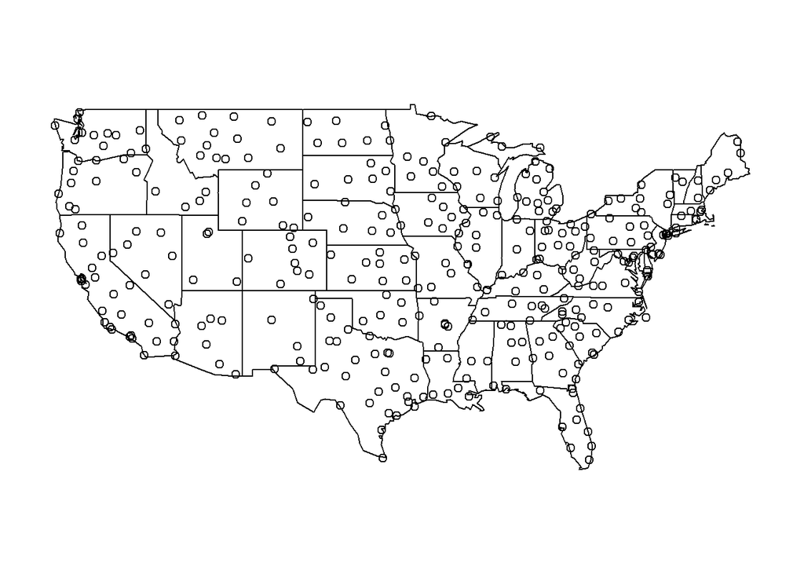

Figure 1. Annual-Average Temperature data for the Continental United States

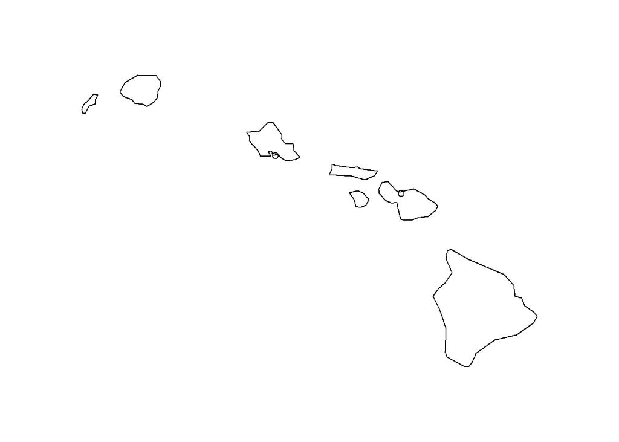

Figure 2. Annual-Average Temperature data for Hawaii

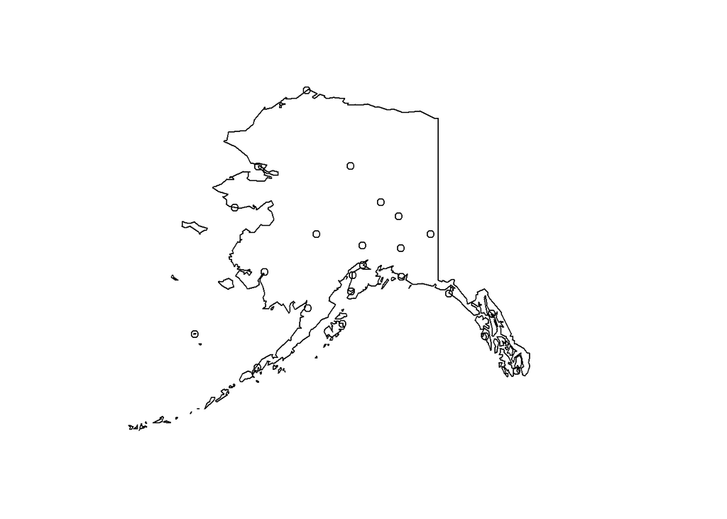

Figure 3. Annual-Average Temperarura data for Alaska

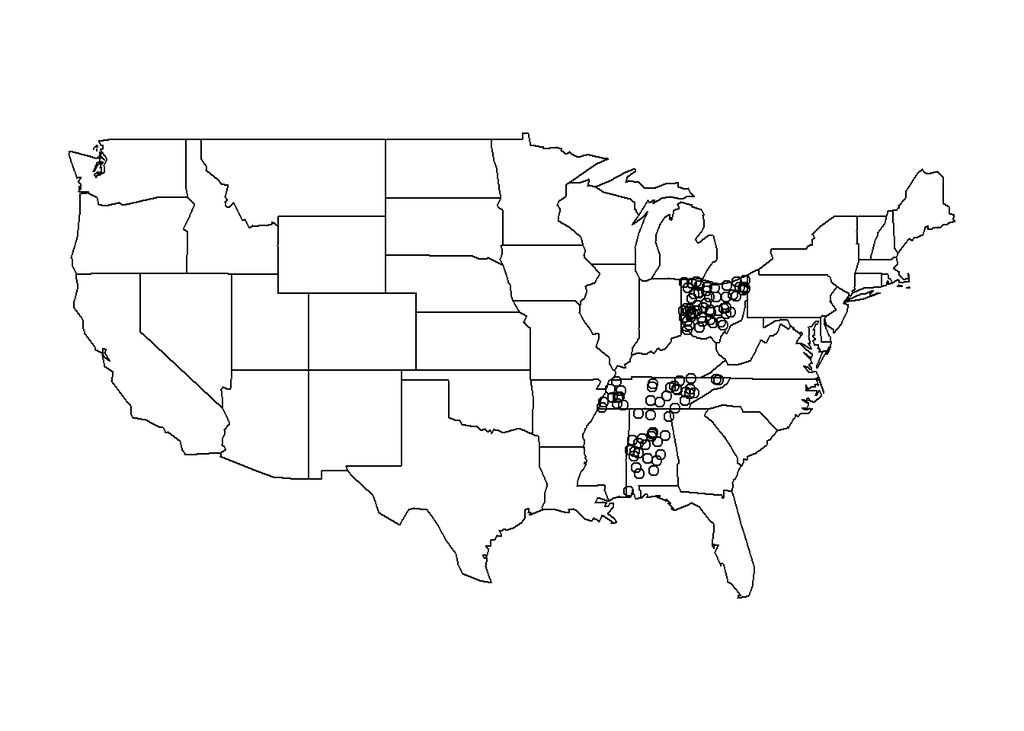

[figure not shown]

[figure not shown]

## Discussion

Can we see the climate warming?

Where is it getting warmer?

Where is it getting colder?

Where is it staying the same?

What does the change in presipitation look like? How does it compare to changes in temperature?